# 01_clases_s4_mapas.Rmd

Caio Moreno

Los ejercicios tienen que resolverse individualmente. No son sencillos: parte de ellos están inspirados en problemas prácticos reales. Por eso puedes ayudarte de cualquier tipo de instrumento (Google, blogs, libros, etc.) que estaría a tu alcance en tu trabajo. Eso sí, en las soluciones que envíes, indica los recursos que utilices y deja clara cuál es tu aportación en cada caso.

El envío de los ficheros se hará por medio del Blackboard. La fecha límite para puntuar sobre 10 es tres semanas después de la clase. A partir de entonces, la nota máxima bajará dos puntos por semana.

A pesar de que hay 14 puntos en juego, las prácticas se evaluarán sobre 10, que es la máxima nota.

### Formato de entrega

1. `dat`, donde almacenarás los datos necesarios y solo los necesarios (piensa que alguno de los ficheros que te pido que uses ocupa muchos megas) para la resolución de los ejercicios. Véanse las excepciones en el enunciado de los ejercicios.
2. `src`, donde estarán los ficheros `.Rmd` y los ficheros `.html` o `.pdf` que generes. Los ficheros tienen que tener un nombre del tipo `01_clases_s4_mapas.Rmd`, `02_json_xml.Rmd` o similar.

En cada ejercicio se valorará con un 25% de la puntuación final que el fichero `.Rmd` se ejecute y lo haga en un tiempo razonable sin ningún tipo de edición por mi parte.

## Ejercicio 01 - Clases S4 y mapas (2 puntos)

Obtén *shapefiles* de, p.e., provincias españolas (el INE los proporciona). Luego, obtén datos de algún tipo de estadística asociada a dichas entidades (población, tasa de desempleo, etc.). Con esos dos elementos, crea un `SpatialPolygonsDataFrame` y represéntalos gráficamente.

Ten en cuenta que si la variable que quieres representar es continua, espero que utilices una escala de colores que muestre las variaciones en la estadística en términos de la intensidad.

Trata de hacerlo *reproduciblemente* (¿con R MarkDown?).

## Ejercicio 01 - Clases S4 y mapas (2 puntos) - Resolución

```r
#
# Caio Moreno
# twitte.com/caiomsouza
# github.com/caiomsouza
# caiomsouza@gmail.com
#
# Recursos utilizados:
# http://cran.r-project.org/doc/contrib/intro-spatial-rl.pdf

# Load all libraries
if (!(require("rgeos", character.only=T, quietly=T))) {
  install.packages("rgeos")
  library("rgeos", character.only=T)
}
```

```
## rgeos version: 0.3-11, (SVN revision 479)
##  GEOS runtime version: 3.4.2-CAPI-1.8.2 r3921
##  Linking to sp version: 1.1-0
##  Polygon checking: TRUE
```

```r
if (!(require("maptools", character.only=T, quietly=T))) {
  install.packages("maptools")
  library("maptools", character.only=T)
}
```

```
## Checking rgeos availability: TRUE
```

```r
library(rgdal)
```

```r
if (!(require("maptools", character.only=T, quietly=T))) {
  install.packages("maptools")
  library("maptools", character.only=T)
}

library(ggplot2)

if (!(require("maptools", character.only=T, quietly=T))) {
  install.packages("maptools")
  library("maptools", character.only=T)
}

library(rgeos)

if (!(require("maptools", character.only=T, quietly=T))) {
  install.packages("maptools")
  library("maptools", character.only=T)
}

library(maptools)

if (!(require("maptools", character.only=T, quietly=T))) {
  install.packages("maptools")
  library("maptools", character.only=T)
}

library(plyr)
if (!(require("maptools", character.only=T, quietly=T))) {
  install.packages("maptools")
  library("maptools", character.only=T)
}

library(reshape2)

if (!(require("maptools", character.only=T, quietly=T))) {
  install.packages("maptools")
  library("maptools", character.only=T)
}


# Establecer el directorio de trabajo antes de ejecutarlo
setwd("~/git/Bitbucket/u-tad/Mod7/carlos.bellosta/ejercicios-entregues")

# Cargamos los shapefiles y lo formateamos para que pueda ser representado por ggplot2
provincias.Espana <- readOGR(dsn = "dat/Provincias_ETRS89_30N","Provincias_ETRS89_30N")
typeof(provincias.Espana)
```

```
## [1] "S4"
```

```r
provincias.Espana.df <- fortify(provincias.Espana, region = "Codigo")
head(provincias.Espana.df)
```

```
##       long     lat order  hole piece group id
## 1 497823.7 4784874     1 FALSE     1  01.1 01
## 2 498456.8 4784220     2 FALSE     1  01.1 01
## 3 498532.3 4783866     3 FALSE     1  01.1 01
## 4 498382.2 4783793     4 FALSE     1  01.1 01
## 5 498945.7 4783509     5 FALSE     1  01.1 01
## 6 499045.7 4782937     6 FALSE     1  01.1 01
```

```r
provincias.Espana.df <- merge(provincias.Espana.df, provincias.Espana@data, by.x = "id", by.y = "Codigo")

# Cargamos y limpiamos el df con los viajeros entrados por provincia en los últimos años (2011, 2012 y 2013 - Encuesta de ocupación hotelera)

# Arreglar eso cambiar el lapply(11:13) eso es para cargar los ficheiros de 11 a 13

tmp <- lapply(c(11:13), function(x)
                        read.table(paste(paste("dat/viajeros_provincias_20", x, sep = ""), ".csv", sep = ""), sep = ";", header = T, encoding = "UTF-8"))
# No se indican las columnas de unión, lo coge automáticamente por provincia.
viajeros.Espana <- join(join(tmp[[1]], tmp[[2]]), tmp[[3]])
viajeros.Espana <- viajeros.Espana[,-3]
colnames(viajeros.Espana)[2:4] <- c("2011", "2012", "2013")

provincias.Espana$Texto %in% viajeros.Espana$Provincia
```

```
##  [1]  TRUE  TRUE  TRUE  TRUE  TRUE  TRUE  TRUE  TRUE  TRUE  TRUE  TRUE
## [12]  TRUE  TRUE  TRUE  TRUE  TRUE FALSE  TRUE  TRUE FALSE  TRUE  TRUE
## [23]  TRUE  TRUE  TRUE  TRUE  TRUE  TRUE  TRUE  TRUE  TRUE FALSE  TRUE
## [34]  TRUE  TRUE  TRUE  TRUE  TRUE  TRUE  TRUE  TRUE  TRUE  TRUE  TRUE
## [45]  TRUE  TRUE  TRUE FALSE  TRUE  TRUE  TRUE  TRUE
```

```r
provincias.Espana$Texto[which(!(provincias.Espana$Texto %in% viajeros.Espana$Provincia))]
```

```
## [1] Gerona    Guipúzcoa Orense    Vizcaya
## 52 Levels: Álava Albacete Alicante Almería Asturias Ávila ... Zaragoza
```

```r
levels(viajeros.Espana$Provincia)
```

```
##  [1] "Álava"                  "Albacete"
##  [3] "Alicante"               "Almería"
##  [5] "Asturias"               "Ávila"
##  [7] "Badajoz"                "Barcelona"
##  [9] "Bizkaia"                "Burgos"
## [11] "Cáceres"                "Cádiz"
## [13] "Cantabria"              "Castellón"
## [15] "Ceuta"                  "Ciudad Real"
## [17] "Córdoba"                "Cuenca"
## [19] "Gipuzkoa"               "Girona"
## [21] "Granada"                "Guadalajara"
## [23] "Huelva"                 "Huesca"
## [25] "Islas Baleares"         "Jaén"
## [27] "La Coruña"              "La Rioja"
## [29] "Las Palmas"             "León"
## [31] "Lleida"                 "Lugo"
## [33] "Madrid"                 "Málaga"
## [35] "Melilla"                "Murcia"
## [37] "Navarra"                "Ourense"
## [39] "Palencia"               "Pontevedra"
## [41] "Salamanca"              "Santa Cruz de Tenerife"
## [43] "Segovia"                "Sevilla"
## [45] "Soria"                  "Tarragona"
## [47] "Teruel"                 "Toledo"
## [49] "Valencia"               "Valladolid"
## [51] "Zamora"                 "Zaragoza"
```

```r
# Se indexa con un factor, si fuera character no se podría
levels(viajeros.Espana$Provincia)[viajeros.Espana$Provincia[which(!(viajeros.Espana$Provincia %in% provincias.Espana$Texto))]] <- c("Vizcaya", "Guipúzcoa", "Gerona", "Orense")
provincias.Espana$Texto %in% viajeros.Espana$Provincia
```

```
##  [1] TRUE TRUE TRUE TRUE TRUE TRUE TRUE TRUE TRUE TRUE TRUE TRUE TRUE TRUE
## [15] TRUE TRUE TRUE TRUE TRUE TRUE TRUE TRUE TRUE TRUE TRUE TRUE TRUE TRUE
## [29] TRUE TRUE TRUE TRUE TRUE TRUE TRUE TRUE TRUE TRUE TRUE TRUE TRUE TRUE
## [43] TRUE TRUE TRUE TRUE TRUE TRUE TRUE TRUE TRUE TRUE
```

```r
# Convertimos en formato largo para trabajar con los datos
viajeros.Espana.melt <- melt(viajeros.Espana, id = "Provincia")

plot.data <- merge(provincias.Espana.df, viajeros.Espana.melt, by.x = "Texto", by.y = "Provincia")
plot.data <- plot.data[order(plot.data$order), ]
#colnames(viajeros.España.melt)[2:3] <- c("año", "visitas")

head(plot.data)
```

```
##   Texto id     long     lat order  hole piece group Texto_Alt Cod_CCAA
## 1 Álava 01 497823.7 4784874     1 FALSE     1  01.1     Araba       16
## 2 Álava 01 497823.7 4784874     1 FALSE     1  01.1     Araba       16
## 3 Álava 01 497823.7 4784874     1 FALSE     1  01.1     Araba       16
## 4 Álava 01 498456.8 4784220     2 FALSE     1  01.1     Araba       16
## 5 Álava 01 498456.8 4784220     2 FALSE     1  01.1     Araba       16
## 6 Álava 01 498456.8 4784220     2 FALSE     1  01.1     Araba       16
##         CCAA variable  value
## 1 País Vasco     2013 315138
## 2 País Vasco     2012 345703
## 3 País Vasco     2011 365972
## 4 País Vasco     2013 315138
## 5 País Vasco     2012 345703
## 6 País Vasco     2011 365972
```

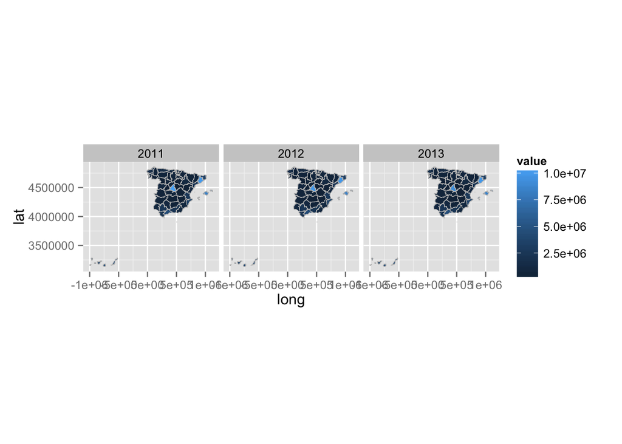

```r
ggplot(data = plot.data, aes(x = long, y = lat, fill = value, group = group)) +
  geom_polygon() + geom_path(colour = "grey", lwd = 0.1) + coord_equal() + facet_wrap(~variable)
```